# Bike usage in Seattle 2014 - 2030

Chris Shaw

12 April 2019

Abstract

##### This paper explores whether Seattle will reach its goal of quadrupling bike usage by 2030, as expressed in their [Bicycle Master Plan](http://www.seattle.gov/transportation/sdot-document-library/citywide-plans/modal-plans/bicycle-master-plan). The data collected from city bike counters forms the basis of the projection model. Overall bike usage is decline across both commuter and leisure users, with the exception of some trails which are projected to show some modest growth in recreational use. However, the goal of quadrupling will not be achieved without some change in the patterns seen over the last five years.

## Data collection

The raw dataset contains counts of bikes and pedestrians in Seattle at hourly time intervals over a five year period 2013 - 2018. Counters were placed on different routes in the city and measure the direction of travel

This paper contains a summary of the steps and conclusion. The full analysis [can be found here](https://github.com/connectedblue/tidytuesday/blob/master/data/2019/2019-04-02/seattle_bikes.Rmd).

The purpose of segmenting the data this way is to determine whether leisure or commuter use of bikes is trending upwards or downwards. While it is certainly true that people commute outside these times, it will be seen that overall there is a large directional spike in usage during this period that we are justified in labelling it as commuter usage.

```r
# read in the data from disk - can uncomment the line below to retrieve from github if required
#bike_traffic <- readr::read_csv("https://raw.githubusercontent.com/rfordatascience/tidytuesday/master/data/2019/2019-04-02/bike_traffic.csv")
bike_traffic <- readr::read_csv("bike_traffic.csv")

# Fix date column and remove two routes missing a lot of data
bike_traffic <- bike_traffic %>%
                mutate(datetime=mdy_hms(date),
                       date=floor_date(datetime, 'day'),
                       week=floor_date(datetime, 'week'),
                       hour=hour(datetime),
                       day=ordered(weekdays(datetime),levels=c("Monday", "Tuesday",
                                                               "Wednesday", "Thursday",
                                                               "Friday", "Saturday", "Sunday")),
                       month=as.Date(paste0(year(datetime),'-',month(datetime),'-01')),
                       weekend=(day %in% c("Saturday", "Sunday")),
                       usage=if_else(hour %in% c(22,23,0,1,2,3,4,5,6), 'overnight',
                             if_else(((hour %in% c(6,7,8,16,17,18)) & weekend==FALSE),
                                     'commuter', 'leisure' ))
                        ) %>%
                filter(!(crossing %in% c('NW 58th St Greenway at 22nd Ave',
                                         'Sealth Trail')),
                       !is.na(bike_count), bike_count!=0)
```

## Peak and non peak times

First we look at the average bike count on each route direction on different hours of the day. We don’t split out weekends at this stage, nor do we compare different years. We can get a feel for where spikes in usage occur which help to classify between the different types of usage.

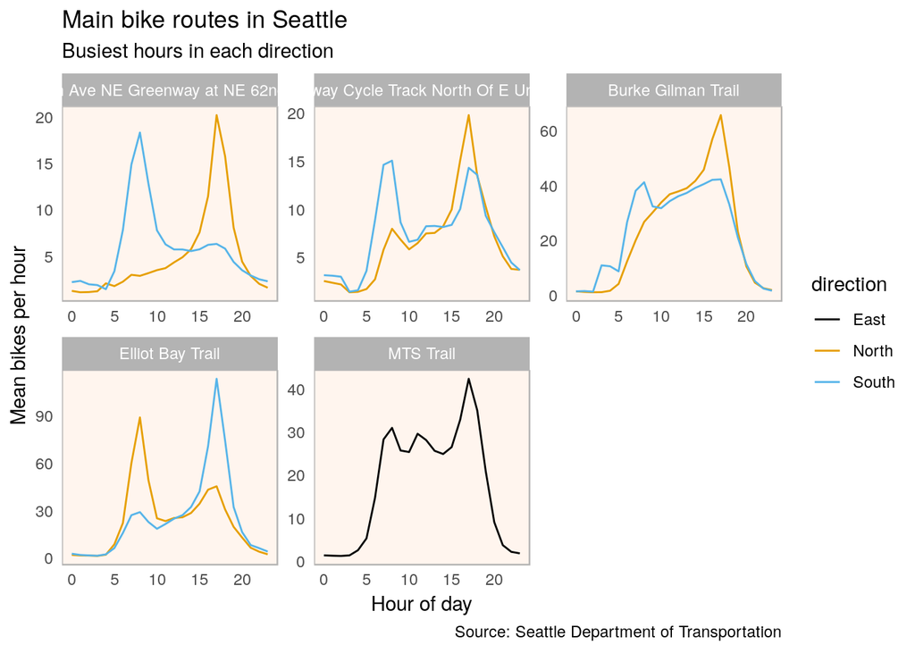

```r
bike_traffic %>%
  group_by(crossing, direction, hour) %>%
  summarise(ave_hourly_bike_count=mean(bike_count, na.rm = TRUE)) %>%
ggplot(aes(x=hour, y=ave_hourly_bike_count, col=direction)) +
  geom_line() +
  facet_wrap(.~crossing,scales = 'free') +
  labs(title='Main bike routes in Seattle ',
          subtitle='Busiest hours in each direction',
          x='Hour of day',y='Mean bikes per hour') +
  theme
```

It can be clearly seen that each route has a pronounced peak in usage in the early morning and late afternoon. Furthermore, there is a direction switch in those routes later in the day.

As an example, 39th Ave NE shows almost the same number of people biking south in the morning as going north in the evening, with little in between. This suggests it is largely a one way commuter route with perhaps little leisure utility.

## Weekend versus weekday use

We can refine this view further by looking how direction varies between weekdays and weekends on the routes.

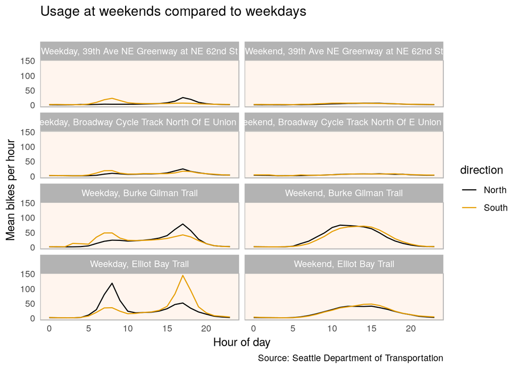

```r
bike_traffic %>%
  filter(crossing!='MTS Trail') %>%
  group_by(weekend, crossing, direction, hour) %>%
  summarise(ave_hourly_bike_count=mean(bike_count, na.rm = TRUE)) %>%
  ungroup() %>%
  mutate(weekend=if_else(weekend, 'Weekend', 'Weekday')) %>%
ggplot(aes(x=hour, y=ave_hourly_bike_count, col=direction)) +
  geom_line() +
  facet_wrap(.~weekend+crossing,nrow=4, dir='v', labeller = label_wrap_gen(width=80, multi_line = FALSE)) +
  labs(title='Usage at weekends compared to weekdays',
       subtitle='',
       x='Hour of day',y='Mean bikes per hour') +
  theme
```

Now we can see much more clearly that direction in peak hours during the week really matters to bike users, whereas during weekends, no one direction dominates.

Finally, we can see see if some routes might be more geared toward leisure usage rather than commuting.

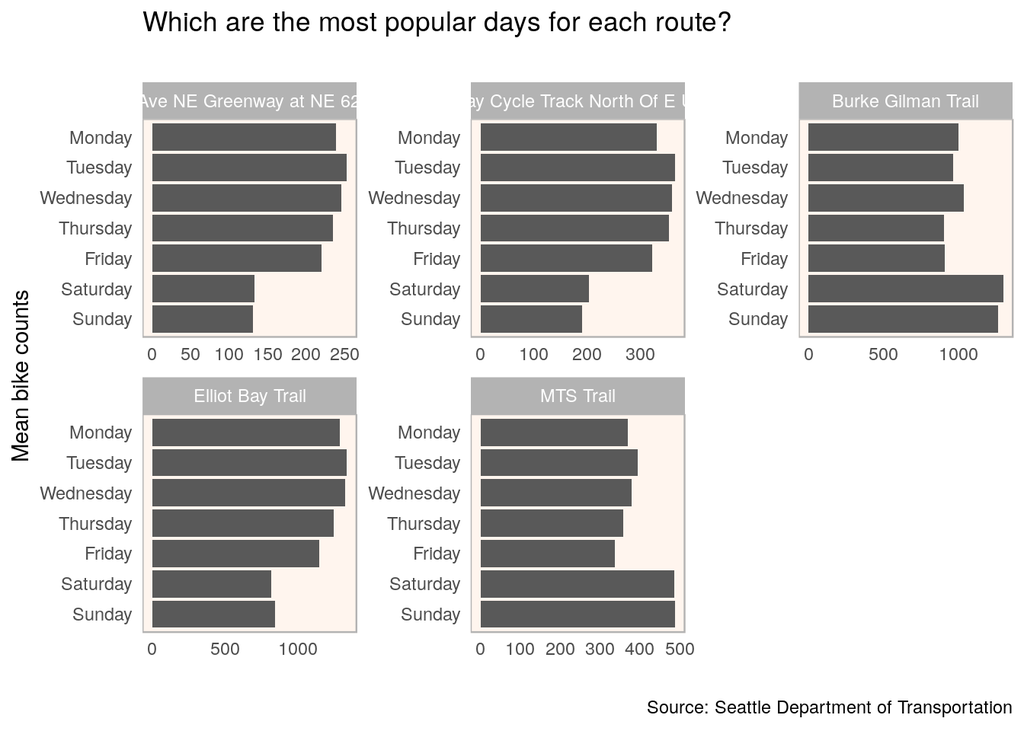

```r
bike_traffic %>%
  group_by(crossing, date, day) %>%
  summarise(daily_bike_count=sum(bike_count, na.rm = TRUE)) %>%
  ungroup() %>%
  group_by(crossing, day) %>%
  summarise(ave_bike_count_for_day=mean(daily_bike_count, na.rm = TRUE)) %>%
ggplot(aes(x=reorder(day, desc(day)), y=ave_bike_count_for_day)) +
  geom_bar(stat ='identity') +
  coord_flip() +
  facet_wrap(.~crossing,scales = 'free') +
  labs(title='Which are the most popular days for each route?',
       subtitle='',
       x='Mean bike counts',y='') +
  theme +
  theme(legend.position=c(.85,.25))
```

The routes that are named Trails are the most heavily used, suggesting they are dedicated facilities.

## Will bike usage increase over time?

Seattle has a [Bicycle Master Plan](http://www.seattle.gov/transportation/sdot-document-library/citywide-plans/modal-plans/bicycle-master-plan) which aims to quadruple bike journeys by 2030.

We can build a projection of future usage based on the last five years of data, to see whether they are on track for this goal. The commuter and leisure projections are modelled separately. First the model is trained using the `prophet` package

```r
# running a logistic prediction means that a floor and a cap has to be specified in both the
# historic and future data.
# This prevents the number of bikes per week falling below zero
cap <- 100000
floor <- 0

training <- bike_traffic %>%
  group_by( usage, crossing, week) %>%
  summarise(y=sum(bike_count, na.rm = TRUE)) %>%
  ungroup() %>%
  mutate(ds=week) %>%
  select (ds,usage,crossing,y) %>%
  mutate(cap=cap,floor=floor) %>%
  group_by(usage,crossing) %>%
  nest(-usage, -crossing) %>%
  mutate(
         m = map(.$data, prophet, growth = 'logistic'),
         future = map(m, make_future_dataframe, periods = 600, freq='week'),
         future = map(future, ~ .x %>%  mutate(cap=cap,floor=floor)),
         forecast = map2(m, future, predict)
         ) %>%
  unnest(forecast) %>%
  select(ds, usage, crossing, yhat)
```

We then plot the values from the model.

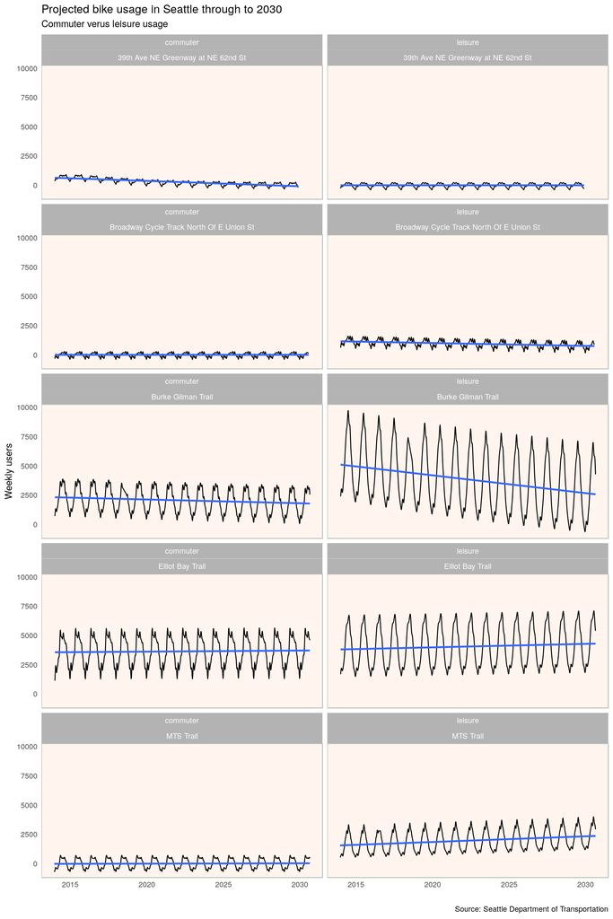

```r
training %>%
  filter(usage!='overnight') %>%
ggplot(aes(x=ds, y=yhat)) +
  geom_line() +
  geom_smooth(method = "lm", se = FALSE) +
  facet_wrap(.~usage+crossing, nrow=5, dir = 'v', scales='fixed') +
  labs(title='Projected bike usage in Seattle through to 2030',
       subtitle='Commuter verus leisure usage',
       x='',y='Weekly users') +
  theme +
  theme(legend.position=c(.85,.25))
```

Sadly, bike usage appears to be declining on a number of routes, from both a commuting and leisure persepctive.

Notable exceptions though are the MTS and Elliot Bay Trails. However, overall usage is unlikely to quadruple over the next ten years if the trends in the last five continue.